# Distribution of H3K4me3 across the gene body

John Blischak

**Last updated:** 2015-10-22

**Code version:** 044491cd5df4302bbdcf97ec1313fa184fc31516

```r
library("knitr")
opts_chunk$set(fig.align = "center", fig.width = 10)
```

## Setup

```r
library("edgeR")
library("tidyr")
library("dplyr")
library("ggplot2")
library("cowplot")
theme_set(theme_bw(base_size = 12))
```

Read in the featureCounts results for assigning reads to the 50 bins for each gene.

```r
anno <- read.table("../../data/yeast/annotation.txt", header = TRUE, sep = "\t",
                   stringsAsFactors = FALSE)
bin_files <- list.files("../../data/yeast/counts", glob2rx("bins*txt"),
                        full.names = TRUE)
counts <- readDGE(files = bin_files, columns = c(1, 7), skip = 1,
                  labels = sub(".sorted.rmdup_genecounts.txt", "", basename(bin_files)))
stopifnot(grep("input", anno$sample, ignore.case = TRUE) ==
          grep("input", colnames(counts), ignore.case = TRUE),
          grep("aa", anno$sample, ignore.case = TRUE) ==
          grep("aa", colnames(counts), ignore.case = TRUE),
          grep("full", anno$sample, ignore.case = TRUE) ==
          grep("full", colnames(counts), ignore.case = TRUE))
colnames(counts) <- anno$sample
head(counts$counts)
```

```
##            H3K4me3.aa762_1080.r1 H3K4me3.aa762_1080.r2
## YAL067C;50                     5                     6
## YAL067C;49                     5                     7
## YAL067C;48                     3                     5
## YAL067C;47                     3                     3
## YAL067C;46                     5                     3
## YAL067C;45                     4                     3
##            H3K4me3.full_length.r1 H3K4me3.full_length.r2
## YAL067C;50                      3                      5
## YAL067C;49                      6                      6
## YAL067C;48                      5                      3
## YAL067C;47                      5                      5
## YAL067C;46                      2                      4
## YAL067C;45                      2                      2
##            input.full_length.r1 input.aa762_1080.r1
## YAL067C;50                   10                  12
## YAL067C;49                   15                  11
## YAL067C;48                   13                  10
## YAL067C;47                    9                  14
## YAL067C;46                    5                  12
## YAL067C;45                    8                   9
```

Calculate the reads per million (rpm), and then subtract the input rpm from the IP rpm.

```r
counts_cpm <- cpm(counts)
counts_cpm <- as.data.frame(counts_cpm)
counts_cpm$H3K4me3.aa762_1080.r1 <- counts_cpm$H3K4me3.aa762_1080.r1 -
                                counts_cpm$input.aa762_1080.r1
counts_cpm$H3K4me3.aa762_1080.r2 <- counts_cpm$H3K4me3.aa762_1080.r2 -
                                counts_cpm$input.aa762_1080.r1
counts_cpm$H3K4me3.full_length.r1 <- counts_cpm$H3K4me3.full_length.r1 -
                                 counts_cpm$input.full_length.r1
counts_cpm$H3K4me3.full_length.r2 <- counts_cpm$H3K4me3.full_length.r2 -
                                 counts_cpm$input.full_length.r1
counts_cpm_std <- counts_cpm %>% select(contains("H3K4me3"))
head(counts_cpm_std)
```

```
##            H3K4me3.aa762_1080.r1 H3K4me3.aa762_1080.r2
## YAL067C;50             -3.241663             -3.664191
## YAL067C;49             -2.860495             -3.131384
## YAL067C;48             -3.012270             -3.053493
## YAL067C;47             -4.536944             -4.881444
## YAL067C;46             -3.241663             -4.119107
## YAL067C;45             -2.364629             -2.975601
##            H3K4me3.full_length.r1 H3K4me3.full_length.r2
## YAL067C;50              -2.205232              -1.958573
## YAL067C;49              -3.014799              -3.187686
## YAL067C;48              -2.651899              -3.129073
## YAL067C;47              -1.535368              -1.679440
## YAL067C;46              -1.004933              -0.729460
## YAL067C;45              -1.842332              -1.899960
```

Prepare the data for plotting by each bin.

```r
counts_cpm_std <- cbind(rownames(counts_cpm_std), counts_cpm_std)
colnames(counts_cpm_std)[1] <- "gene_num"
counts_cpm_std <- separate(counts_cpm_std, col = gene_num,
                           into = c("gene", "bin"), sep = ";")
write.table(counts_cpm_std, "../../data/yeast/counts-cpm-std.txt", sep = "\t",
            quote = FALSE, row.names = FALSE, col.names = TRUE)
counts_long <- gather(counts_cpm_std, key = "sample", value = "cpm",
                      H3K4me3.aa762_1080.r1:H3K4me3.full_length.r2)
metagene <- counts_long %>%
  group_by(sample, bin) %>%
  summarize(mean = mean(cpm),
            sem = sd(cpm) / sqrt(n()))
metagene$bin <- as.numeric(metagene$bin)
metagene$sample <- factor(metagene$sample,
                          levels = c("H3K4me3.full_length.r1",
                                     "H3K4me3.full_length.r2",
                                     "H3K4me3.aa762_1080.r1",
                                     "H3K4me3.aa762_1080.r2"),
                          labels = c("H3K4me3 full length Rep 1",
                                     "H3K4me3 full length Rep 2",
                                     "H3K4me3 aa762-1080 Rep 1",
                                     "H3K4me3 aa762-1080 Rep 2"))
```

This analsysis uses 5124 genes.

## Plot

Plot the metagene result.

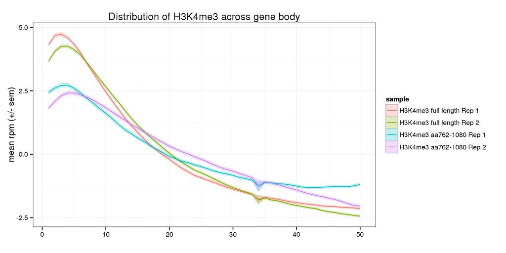

```r
ggplot(metagene, aes(x = bin, y = mean)) +
  geom_line(aes(color = sample)) +
  geom_ribbon(aes(ymin = mean - sem, ymax = mean + sem, fill = sample),
              alpha = 0.25) +
  labs(x = "", y = "mean rpm (+/- sem)",
       title = "Distribution of H3K4me3 across gene body")
```

In addition to the lower H3K4me3 at the TSS, there is higher H3K4me3 in the gene body for the yeast with the truncated Set1.

## Test

Are the observed differences in the metagene plot statistically significant?

Merge the annotation information.

```r
counts_long <- merge(counts_long, anno[, c("set1", "sample")], by = "sample")
```

For each gene in each bin, calculate the mean between the two replicates.

```r
counts_long_mean <-  counts_long %>%
  group_by(set1, gene, bin) %>%
  summarize(mean_cpm = mean(cpm))
head(counts_long_mean)
```

```
## Source: local data frame [6 x 4]
## Groups: set1, gene
##
##         set1  gene bin  mean_cpm
## 1 aa762_1080 Q0045   1 -124.0861
## 2 aa762_1080 Q0045  10 -158.0214
## 3 aa762_1080 Q0045  11 -161.5556
## 4 aa762_1080 Q0045  12 -157.4241
## 5 aa762_1080 Q0045  13 -136.6965
## 6 aa762_1080 Q0045  14 -139.6249
```

Take the mean across bins 1-10 and bins 31-40, and also calculate the difference in these two means.

```r
counts_long_mean_bin <-  counts_long_mean %>%
  filter(bin %in% c(1:10, 31:40)) %>%
  group_by(set1, gene) %>%
  summarize(mean_tss = mean(mean_cpm[bin %in% 1:10]),
            mean_body = mean(mean_cpm[bin %in% 31:40]),
            difference = mean_tss - mean_body)
stopifnot(length(unique(counts_long_mean_bin$gene)) * 2 ==
          nrow(counts_long_mean_bin))
head(counts_long_mean_bin)
```

```
## Source: local data frame [6 x 5]
## Groups: set1
##
##         set1  gene   mean_tss  mean_body  difference
## 1 aa762_1080 Q0045 -145.23272 -134.35190 -10.8808195
## 2 aa762_1080 Q0050  -45.74124  -47.32702   1.5857750
## 3 aa762_1080 Q0055  -68.85926  -67.96153  -0.8977308
## 4 aa762_1080 Q0060  -79.56069  -84.87930   5.3186101
## 5 aa762_1080 Q0065  -98.05090 -100.03874   1.9878462
## 6 aa762_1080 Q0070 -110.56848 -118.59647   8.0279925
```

How are these distributed?

```
## stat_bin: binwidth defaulted to range/30. Use 'binwidth = x' to adjust this.
## stat_bin: binwidth defaulted to range/30. Use 'binwidth = x' to adjust this.
```

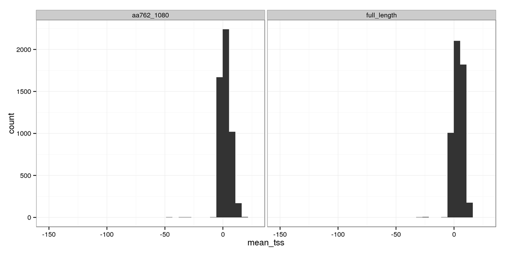

```r
ggplot(counts_long_mean_bin, aes(x = mean_tss)) + geom_histogram() + facet_wrap(~set1)
```

```
## stat_bin: binwidth defaulted to range/30. Use 'binwidth = x' to adjust this.
## stat_bin: binwidth defaulted to range/30. Use 'binwidth = x' to adjust this.
```

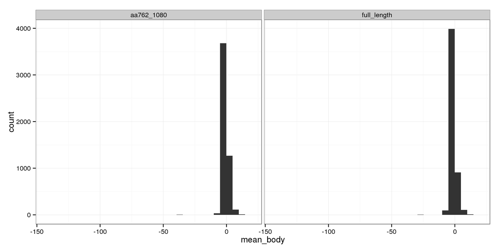

```r
ggplot(counts_long_mean_bin, aes(x = mean_body)) + geom_histogram() + facet_wrap(~set1)
```

```
## stat_bin: binwidth defaulted to range/30. Use 'binwidth = x' to adjust this.
## stat_bin: binwidth defaulted to range/30. Use 'binwidth = x' to adjust this.
```

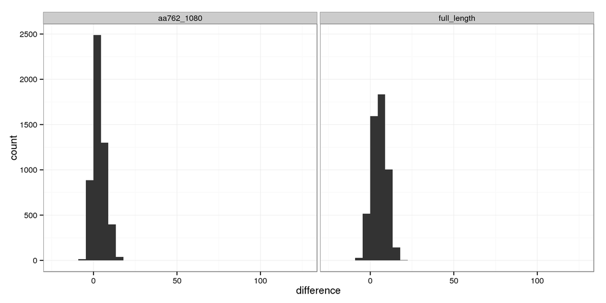

```r
ggplot(counts_long_mean_bin, aes(x = difference)) + geom_histogram() + facet_wrap(~set1)
```

Perform t-tests.

```r
test_mean_tss <- t.test(counts_long_mean_bin$mean_tss[counts_long_mean_bin$set1 == "full_length"],
       counts_long_mean_bin$mean_tss[counts_long_mean_bin$set1 == "aa762_1080"])
test_mean_body <- t.test(counts_long_mean_bin$mean_body[counts_long_mean_bin$set1 == "full_length"],
       counts_long_mean_bin$mean_body[counts_long_mean_bin$set1 == "aa762_1080"])
test_difference <- t.test(counts_long_mean_bin$difference[counts_long_mean_bin$set1 == "full_length"],
       counts_long_mean_bin$difference[counts_long_mean_bin$set1 == "aa762_1080"])
```

They are all highly significant.

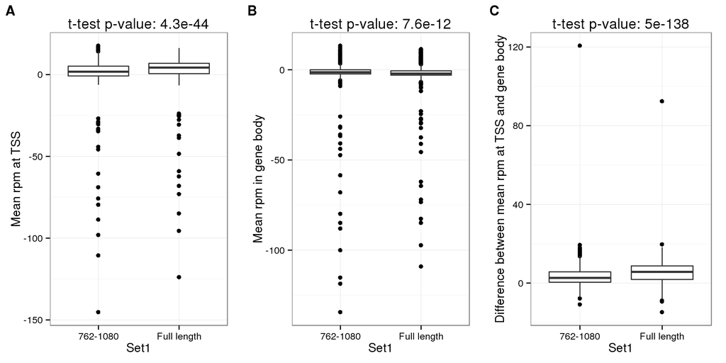

```r
plot_mean_tss <- ggplot(counts_long_mean_bin, aes(x = set1, y = mean_tss)) +
  geom_boxplot() +
  scale_x_discrete(labels = c("aa762_1080" = "762-1080",
                              "full_length" = "Full length")) +
  labs(x = "Set1", y = "Mean rpm at TSS",
       title = paste("t-test p-value:", format(test_mean_tss$p.value, digits = 2)))
plot_mean_body <- plot_mean_tss %+% aes(y = mean_body) +
  labs(x = "Set1", y = "Mean rpm in gene body",
       title = paste("t-test p-value:", format(test_mean_body$p.value, digits = 2)))
plot_mean_difference <- plot_mean_tss %+% aes(y = difference) +
  labs(x = "Set1", y = "Difference between mean rpm at TSS and gene body",
       title = paste("t-test p-value:", format(test_difference$p.value, digits = 2)))
plot_grid(plot_mean_tss, plot_mean_body, plot_mean_difference, nrow = 1,
          labels = LETTERS[1:3])
```